# Isolating Cycling Cells in Mice and Calculating Proportions

Larry Chen

2022-10-24

This R Markdown file will take you through the process of isolating cycling IFE cells in mice, calculating the proportion of overall cycling cells, and calculating proportion of basal/spinous cells that are cycling.

## Libraries

```r
library(Seurat)
library(SeuratObject)
library(patchwork)
library(dplyr)
library(ggplot2)
library(reshape2)
library(tibble)
```

# Importing data into R from GEO files

The original CellRanger data was downloaded from the NCBI GEO database. Note: the data from the SHP samples were not used in this analysis. (Accession # GSE165021 https://www.ncbi.nlm.nih.gov/geo/query/acc.cgi?acc=GSE165021)

Keep the barcodes, features, and matrix files for each sample in a separate folder, and place each sample folder into a directory of your choice. Enter the directory path into the “data_dir” variable.

```r
#SET FOLDER NAMES (geo_names)
geo_names = c("GSM5024746-Normal_1","GSM5024747-Normal_2","GSM5024748-IMQ_1","GSM5024749-IMQ_2")
all_data = list()
#import data
for (i in 1:length(geo_names))
{
  data_dir = paste("C:/Users/Ji Lab/Documents/JID manuscript/Psoriasis/",geo_names[i],sep="")
  list.files(data_dir)
  data = Read10X(data.dir = data_dir)
  all_data[[i]] = data
}
allnames = c("Normal_1","Normal_2","IMQ_1","IMQ_2") #assign names for objects
all_obj = list()
```

# INITIAL PREPROCESSING

## Creating Seurat Objects for each sample

```r
#create objects
for (i in 1:length(all_data))
{
  obj <- CreateSeuratObject(counts = all_data[[i]], project = allnames[i])
  obj[["percent.mt"]] <- PercentageFeatureSet(obj, pattern = "^mt-")
  obj = subset(obj, percent.mt < 10 & nFeature_RNA>=200)
  all_obj[[i]] = obj
}

for (i in 1:length(all_obj)) {
  all_obj[[i]] <- NormalizeData(all_obj[[i]], verbose = FALSE)
  all_obj[[i]] <- FindVariableFeatures(all_obj[[i]], selection.method = "vst",
                                       nfeatures = 2000, verbose = FALSE)
}
reference.list <- all_obj
```

## Integrating Seurat Objects

```r
#find integration anchors (LONG STEP)
int.anchors = FindIntegrationAnchors(object.list = reference.list, dims = 1:30)
#integrate data (LONG-ISH STEP)
psor_int_filt <- IntegrateData(anchorset = int.anchors, dims = 1:30)
DefaultAssay(psor_int_filt) <- "integrated"
```

## Seurat Data Processing

```r
psor_int_filt <- ScaleData(psor_int_filt, verbose = FALSE)
psor_int_filt <- RunPCA(psor_int_filt, npcs = 30, verbose = FALSE)
psor_int_filt <- RunUMAP(psor_int_filt, reduction = "pca", dims = 1:30)
```

## Clustering

Clusters are generated at resolutions 0.1, 0.2, 0.4, 0.6, 0.8, 1.0, and 1.2 to help with isolating cells.

```r
all_res = c(0.1,0.2,0.4,0.6,0.8,1.0,1.2)
psor_int_filt <- FindNeighbors(psor_int_filt, dims = 1:30, verbose = T)

for (i in all_res){
  psor_int_filt <- FindClusters(psor_int_filt, resolution = i, verbose = FALSE)
}
```

## Generating UMAPs, Feature Plots, and Marker Lists

These tools were used to identify clusters. UMAPs, Feature Plots, and Marker Lists are generated for every cluster resolution.

### UMAPS

```r
#Generating and Saving UMAPs
setwd('C:/Users/Ji Lab/Documents/JID manuscript/Psoriasis/psor_int_filt')
for (i in 1:length(all_res))
{
  res = all_res[i]
  Idents(psor_int_filt) = paste("integrated_snn_res.",res,sep="")
  png(paste("psor_int_filt_UMAP",res,".png",sep=""), units = "in", height = 5, width = 5.5, res=300)
  p=DimPlot(psor_int_filt, reduction="umap", label=T, pt.size = 1)
  print(p)
  dev.off()
}
```

### Feature Plots

```r
#Generating and Saving Feature Plots
DefaultAssay(psor_int_filt) = "RNA"
genes = list(c("Krt10",'Col17a1'),c("Lor",'Flg','Ivl','Klk7'),c("Mki67",'Pcna','Top2a'), c("Itga6", "Itgb4", "Itgb1", "Krt14", "Krt5",'Col17a1'), c("Krt79","Epcam", "Sox9"))
setwd('C:/Users/Ji Lab/Documents/JID manuscript/Psoriasis/psor_int_filt')
for (i in 1:length(genes))
{
  png(paste("psor_int_filt_",paste(genes[[i]], collapse = '.'),"_noaxes_nolegend.png", sep=""), units = "in", height = 6, width = 10, res=300)
  p= FeaturePlot(object = psor_int_filt, features = genes[[i]], cols = c("lightgrey", "blue"), pt.size = 1)
  p = p + NoLegend() + NoAxes()
  print(p)
  dev.off()
}
```

### Marker Lists

```r
for (i in all_res){
  Idents(psor_int_filt) = paste("integrated_snn_res.", i, sep = '')
  psor_int_filt.markers = FindAllMarkers(psor_int_filt, only.pos = TRUE, min.pct = 0.25, logfc.threshold = 0.25)
  write.csv(psor_int_filt.markers, paste0("C:/Users/Ji Lab/Documents/JID manuscript/Psoriasis/psor_int_filt/psor_int_filt.markers_",i,".csv"))
}
```

# IDENTIFYING IFE-ISH CELLS

Using the feature maps and marker lists, we identified clusters 1,5,6,7,8 and 17 at resolution 0.4 as containing IFE cells.

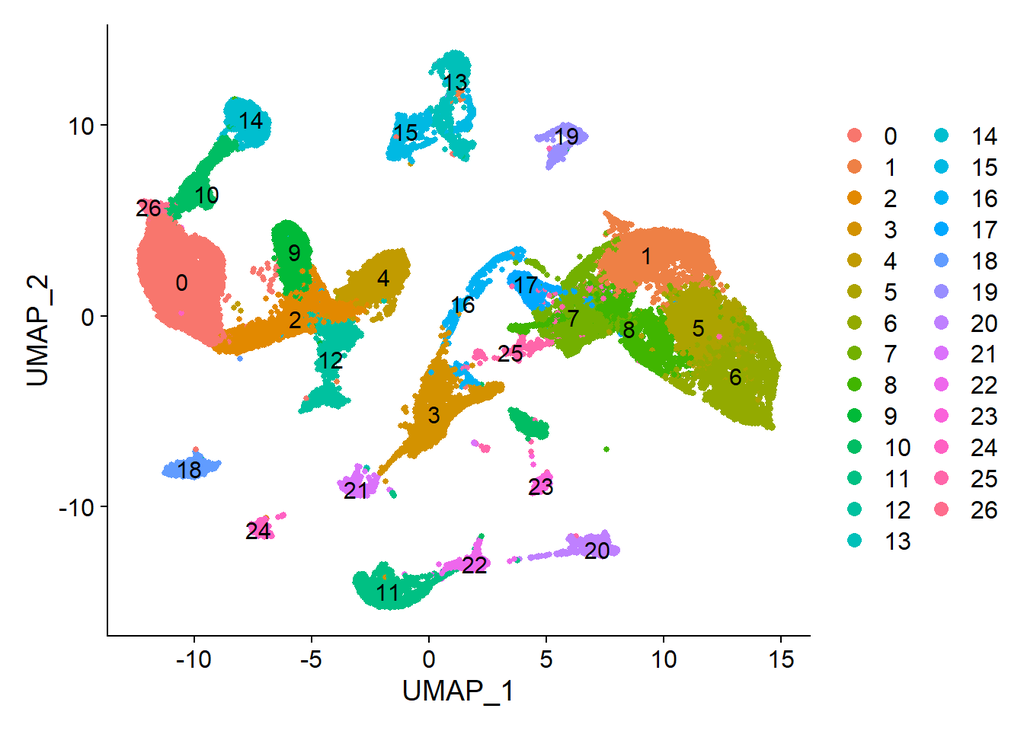

```r
Idents(psor_int_filt) = "integrated_snn_res.0.4"
DimPlot(psor_int_filt, reduction="umap", label=T, pt.size = 1)
```

However, we recognized that these clusters likely had contaminating non-IFE cells. This is evidenced by the presence of cells positive for Cd34, a outer bulge/hair follicle marker.

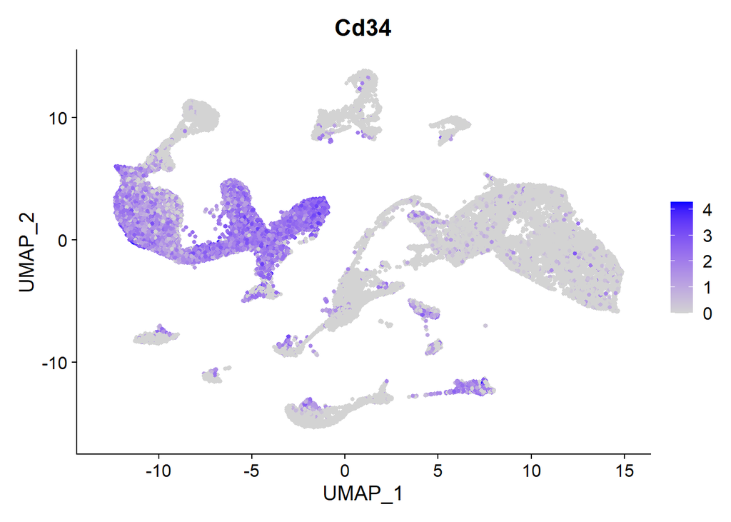

```r
DefaultAssay(psor_int_filt) = "RNA"
FeaturePlot(object = psor_int_filt, features = "Cd34", cols = c("lightgrey", "blue"), pt.size = 1)
```

The next step involves subsetting these ‘IFE-ish’ cells and reclustering them, in order to remove any contaminating non-IFE cells.

```r
Idents(psor_int_filt) = "integrated_snn_res.0.4"
psor_ifeish_no_int = subset(psor_int_filt, idents = c(1,5,6,7,8,17))
```

## Integrating IFE-ish subsets

```r
#reintegration
all_obj <- SplitObject(psor_ifeish_no_int, split.by = "orig.ident")
for (i in 1:length(all_obj)){
  all_obj[[i]] <- NormalizeData(all_obj[[i]], verbose = FALSE)
  all_obj[[i]] <- FindVariableFeatures(all_obj[[i]], selection.method = "vst",
                                           nfeatures = 2000, verbose = FALSE)
}
reference.list <- all_obj
#find integration anchors (LONG)
int.anchors <- FindIntegrationAnchors(object.list = reference.list, dims = 1:30)
#integrate data (LONG-ISH)
psor_ifeish <- IntegrateData(anchorset = int.anchors, dims = 1:30)
DefaultAssay(psor_ifeish) <- "integrated"
dim(psor_ifeish)
```

## Preprocessing

```r
psor_ifeish <- ScaleData(psor_ifeish, verbose = FALSE)
psor_ifeish <- RunPCA(psor_ifeish, npcs = 30, verbose = FALSE)
psor_ifeish <- RunUMAP(psor_ifeish, reduction = "pca", dims = 1:30)
```

## Reclustering

```r
psor_ifeish <- FindNeighbors(psor_ifeish, dims = 1:30, verbose = T)
for (i in all_res){
  psor_ifeish <- FindClusters(psor_ifeish, resolution = i, verbose = FALSE)
}
```

## UMAPs, Feature Plots, and Marker Lists

### UMAPS

```r
#umaps
setwd('C:/Users/Ji Lab/Documents/JID manuscript/Psoriasis/psor_int_filt/psor_ifeish')
for (i in 1:length(all_res))
{
  res = all_res[i]
  Idents(psor_ifeish) = paste("integrated_snn_res.",res,sep="")
  png(paste("psor_ifeish_UMAP",res,".png",sep=""), units = "in", height = 5, width = 5.5, res=300)
  p=DimPlot(psor_ifeish, reduction="umap", label=T, pt.size = 1)
  print(p)
  dev.off()
}
```

### Feature Plots

```r
#feature plots
DefaultAssay(psor_ifeish) = "RNA"
genes = list(c("Krt10",'Col17a1'),c("Lor",'Flg','Ivl','Klk7'),c("Mki67",'Pcna','Top2a'), c("Itga6", "Itgb4", "Itgb1", "Krt14", "Krt5",'Col17a1'), c("Krt79","Epcam", "Sox9"))
setwd('C:/Users/Ji Lab/Documents/JID manuscript/Psoriasis/psor_int_filt/psor_ifeish')
for (i in 1:length(genes))
{
  png(paste("psor_ifeish_",paste(genes[[i]], collapse = '.'),"_noaxes_nolegend.png", sep=""), units = "in", height = 6, width = 10, res=300)
  p= FeaturePlot(object = psor_ifeish, features = genes[[i]], cols = c("lightgrey", "blue"), pt.size = 1)
  p = p + NoLegend() + NoAxes()
  print(p)
  dev.off()
}
```

### Marker Lists

```r
#SAVING MARKER LISTS
all_res = c(0.1,0.2,0.4,0.6,0.8,1.0,1.2)
for (i in all_res){
  Idents(psor_ifeish) = paste("integrated_snn_res.", i, sep = '')
  psor_ifeish.markers = FindAllMarkers(psor_ifeish, only.pos = TRUE, min.pct = 0.25, logfc.threshold = 0.25)
  write.csv(psor_ifeish.markers, paste0("C:/Users/Ji Lab/Documents/JID manuscript/Psoriasis/psor_int_filt/psor_ifeish/psor_ifeish.markers_",i,".csv"))
}
```

# IDENTIFYING IFE CELLS FROM IFE-ISH

At clustering resolution 0.4, we identified clusters 0,1,2,3,4 as IFE cells, and the rest of the clusters as either contaminating hair follicle/outer bulge/inner root sheathe cells (5,6,7,12), sebaceous gland cells (9), fibroblasts (8), or immune cells (10,11).

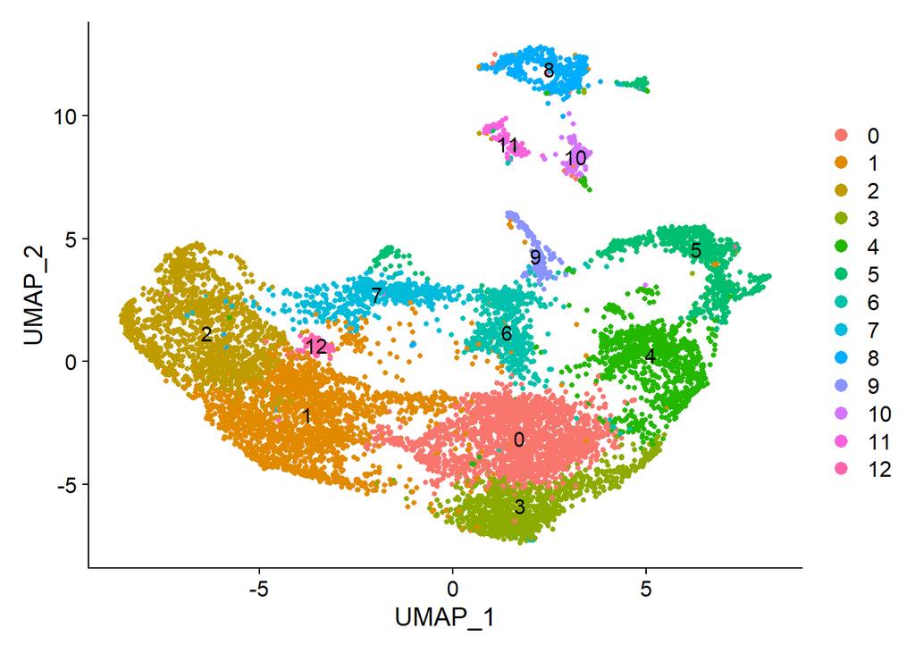

```r
Idents(psor_ifeish) = "integrated_snn_res.0.4"
DimPlot(psor_ifeish, reduction="umap", label=T, pt.size = 1)
```

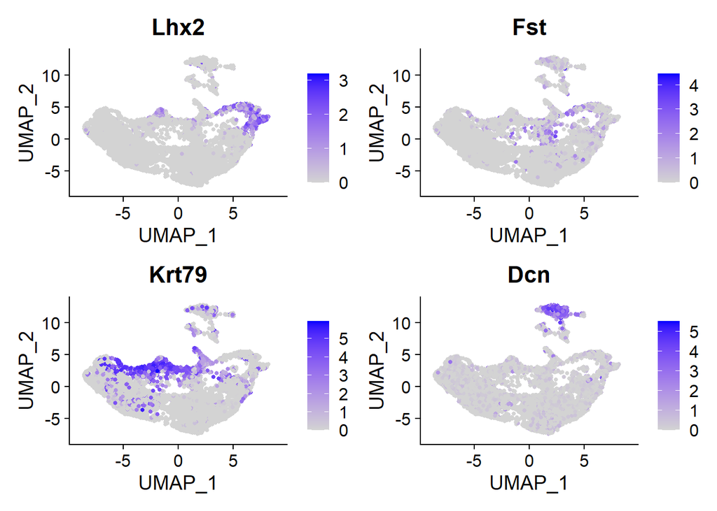

```r
DefaultAssay(psor_ifeish) = "RNA"
FeaturePlot(object = psor_ifeish, features = c("Lhx2","Fst","Krt79","Dcn"), cols = c("lightgrey", "blue"), pt.size = 1)
```

We then took clusters 0,1,2,3,4 as the true IFE cells, and reclustered them, in order to identify basal, spinous, and cycling IFE cells.

## Isolating IFE clusters

```r
Idents(psor_ifeish) = "integrated_snn_res.0.4"
psor_ife_no_int = subset(psor_ifeish, idents = c(0,1,2,3,4))
for (i in 1:length(all_obj)){
  all_obj[[i]] <- NormalizeData(all_obj[[i]], verbose = FALSE)
  all_obj[[i]] <- FindVariableFeatures(all_obj[[i]], selection.method = "vst", nfeatures = 2000, verbose = FALSE)
}
```

## Reintegration

```r
reference.list <- all_obj
#find integration anchors (LONG)
int.anchors <- FindIntegrationAnchors(object.list = reference.list, dims = 1:30)
#integrate data (LONG-ISH)
psor_ife <- IntegrateData(anchorset = int.anchors, dims = 1:30)
DefaultAssay(psor_ife) <- "integrated"
dim(psor_ife)
```

## Preprocessing

In this round of clustering, we also calculate cell cycle scores, to help us identify clusters that consist of mostly cycling cells.

```r
psor_ife <- ScaleData(psor_ife, verbose = FALSE)
psor_ife <- RunPCA(psor_ife, npcs = 30, verbose = FALSE)
psor_ife <- RunUMAP(psor_ife, reduction = "pca", dims = 1:30)
```

## Calculating Cell Cycle Scores

#### Importing list of murine cell cycle genes

```r
mu_s.genes = c("Mcm4", "Exo1", "Slbp", "Gmnn", "Cdc45", "Msh2", "Mcm6", "Rrm2", "Pold3", "Blm",
               "Ubr7", "Mcm5", "Clspn", "Hells", "Nasp", "Rpa2", "Rad51ap1", "Tyms", "Rrm1", "Rfc2",
               "Prim1", "Brip1", "Usp1", "Ung",  "Pola1", "Mcm2", "Fen1", "Tipin", "Pcna", "Cdca7",
               "Uhrf1", "Casp8ap2", "Cdc6", "Dscc1", "Wdr76", "E2f8", "Dtl", "Ccne2", "Atad2", "Gins2",
               "Chaf1b", "Pcna-ps2")
mu_g2m.genes = c("Nuf2", "Psrc1", "Ncapd2", "Ccnb2", "Smc4", "Lbr", "Tacc3", "Cenpa", "Kif23", "Cdca2", "Anp32e",
                 "G2e3", "Cdca3", "Anln", "Cenpe", "Gas2l3", "Tubb4b", "Cenpf", "Dlgap5", "Hjurp", "Cks1brt", "Gtse1",
                 "Bub1", "Birc5", "Ube2c", "Rangap1", "Hmmr", "Ect2", "Tpx2", "Ckap5", "Cbx5", "Nek2", "Ttk",
                 "Cdca8", "Nusap1", "Ctcf", "Cdc20", "Cks2", "Mki67", "Tmpo", "Ckap2l", "Aurkb", "Kif2c", "Cdk1",
                 "Kif20b", "Top2a", "Aurka", "Ckap2", "Hmgb2", "Cdc25c", "Ndc80", "Kif11")
```

#### CellCycleScoring()

```r
DefaultAssay(psor_ife) = 'RNA'
psor_ife <- CellCycleScoring(psor_ife, s.features = mu_s.genes, g2m.features = mu_g2m.genes, set.ident = TRUE)
```

## Clustering

```r
all_res = c(0.1,0.2,0.4,0.6,0.8,1.0,1.2)
psor_ife <- FindNeighbors(psor_ife, dims = 1:30, verbose = T)

for (i in all_res){
  psor_ife <- FindClusters(psor_ife, resolution = i, verbose = FALSE)
}
```

## UMAPs, Feature plots, and Marker Lists

### UMAPs

```r
#umaps
setwd('C:/Users/Ji Lab/Documents/JID manuscript/Psoriasis/psor_int_filt/psor_ifeish/psor_ife')
for (i in 1:length(all_res)){
  res = all_res[i]
  Idents(psor_ife) = paste("integrated_snn_res.",res,sep="")
  png(paste("psor_ife_UMAP",res,".png",sep=""), units = "in", height = 5, width = 5.5, res=300)
  p=DimPlot(psor_ife, reduction="umap", label=T, pt.size = 1)
  print(p)
  dev.off()
}
```

### Feature Plots

```r
DefaultAssay(psor_ife) = "RNA"
genes = list(c("Krt10",'Col17a1'),c("Lor",'Flg','Ivl','Klk7'),c("Mki67",'Pcna','Top2a'), c("Itga6", "Itgb4", "Itgb1", "Krt14", "Krt5",'Col17a1'), c("Krt79","Epcam", "Sox9"))
setwd('C:/Users/Ji Lab/Documents/JID manuscript/Psoriasis/psor_int_filt/psor_ifeish/psor_ife')
for (i in 1:length(genes)){
  png(paste("psor_ife_",paste(genes[[i]], collapse = '.'),"_noaxes_nolegend.png", sep=""), units = "in", height = 6, width = 10, res=300)
  p= FeaturePlot(object = psor_ife, features = genes[[i]], cols = c("lightgrey", "blue"), pt.size = 1)
  p = p + NoLegend() + NoAxes()
  print(p)
  dev.off()
}
```

### Marker Lists

```r
all_res = c(0.1,0.2,0.4,0.6,0.8,1.0,1.2)
for (i in all_res){
  Idents(psor_ife) = paste("integrated_snn_res.", i, sep = '')
  psor_ife.markers = FindAllMarkers(psor_ife, only.pos = TRUE, min.pct = 0.25, logfc.threshold = 0.25)
  write.csv(psor_ife.markers, paste0("C:/Users/Ji Lab/Documents/JID manuscript/Psoriasis/psor_int_filt/psor_ifeish/psor_ife/psor_ife.markers_",i,".csv"))
}
```

### Plotting Cell Cycle Scores

Based on cell cycle scores, Seurat will classify a cell as either in G1, S, or G2M phase. For every cluster, we calculate the proportion of cells in each phase and graph the results. This can be a useful tool for confirming the identity of cycling cell clusters.

```r
#plotting cellcycle score per cluster, for every clustering resolution
all_res = c(0.1,0.2,0.4,0.6,0.8,1.0,1.2)
for (i in all_res){
  #set obj_name
  obj_name = "psor_ife"
  #set identity to i from all_res
  ident = paste0("integrated_snn_res.", i)
  #pull cluster numbers
  clusters = unique(eval(parse(text = paste0(obj_name,"$", ident))))
  #create list to store lists of cell cycle score counts
  cell_cycle_scores = list()
  #iterate through each cluster, calculating how many cells are marked in each phase
  for (c in clusters){
    expr = FetchData(object = eval(parse(text = obj_name)), vars = ident)
    iso_cluster = eval(parse(text = obj_name))[,which(x = expr == c)]
    cluster_S_count = ifelse("S" %in% unique(iso_cluster$Phase),length(WhichCells(iso_cluster, expression = Phase == "S")), 0)
    cluster_G1_count = ifelse("G1" %in% unique(iso_cluster$Phase),length(WhichCells(iso_cluster, expression = Phase == "G1")), 0)
    cluster_G2M_count = ifelse("G2M" %in% unique(iso_cluster$Phase),length(WhichCells(iso_cluster, expression = Phase == "G2M")),0)
    cell_cycle_scores = append(cell_cycle_scores, list(c(cluster_S_count, cluster_G1_count, cluster_G2M_count)))
  }
  #transpose results and format as dataframe w/ col and row names
  cell_cycle_scores_df = as.data.frame(t(as.data.frame(cell_cycle_scores)))
  colnames(cell_cycle_scores_df) = c("S","G1","G2M")
  rownames(cell_cycle_scores_df) = clusters
  #convert raw counts into proportions
  cell_cycle_proportions_df = cell_cycle_scores_df
  #note: when creating a new dataframe to store proportions, need to transpose
  cell_cycle_proportions_df <- as.data.frame(t(apply(cell_cycle_proportions_df, 1, function(i) i/sum(i))))
  cell_cycle_proportions_df = rownames_to_column(cell_cycle_proportions_df, "cluster")
  cell_cycle_proportions_df$S_G2M = cell_cycle_proportions_df$S + cell_cycle_proportions_df$G2M
  #create melted dataframe in preparation for ggplot
  cell_cycle_proportions_dfm <- melt(cell_cycle_proportions_df[,c('cluster','S','G1',"G2M","S_G2M")],id.vars = 1)

  #plot and save
  setwd("C:/Users/Ji Lab/Documents/JID manuscript/Psoriasis/psor_int_filt/psor_ifeish/psor_ife")
  png(paste(obj_name,"_prop_",i,".png",sep=""), units = "in", height = 5, width = 5.5, res=300)
  p = ggplot(cell_cycle_proportions_dfm,aes(x = cluster,y = value)) +
    geom_bar(aes(fill = variable),stat = "identity",position = "dodge") + xlab("Cluster") + ylab("Proportion") + ggtitle(paste0(obj_name, " cell cycle proportions, res: ", i ))
  print(p)
  dev.off()
}
```

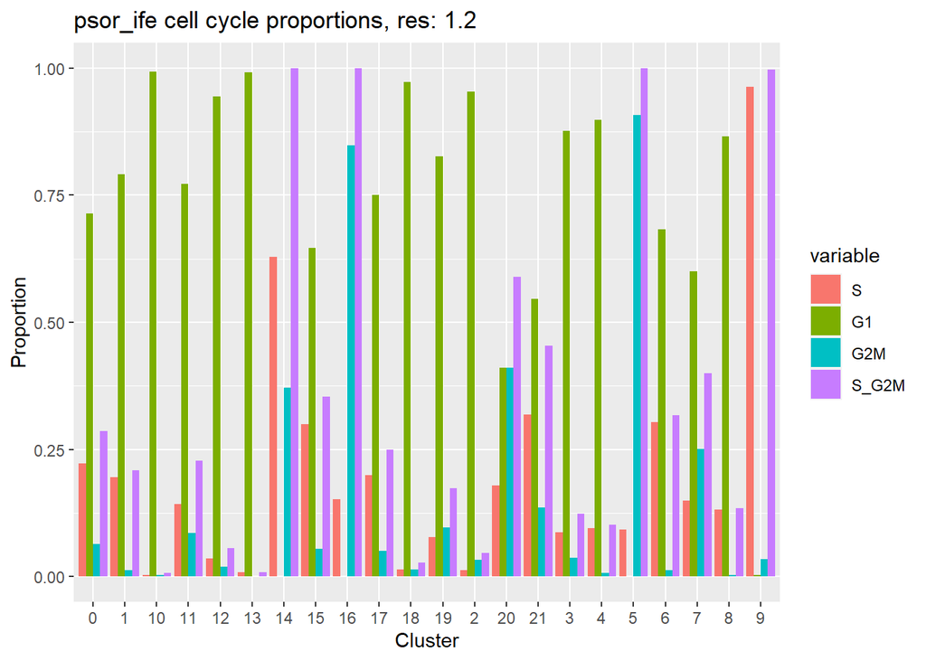

```r
ggplot(cell_cycle_proportions_dfm,aes(x = cluster,y = value)) +
    geom_bar(aes(fill = variable),stat = "identity",position = "dodge") + xlab("Cluster") + ylab("Proportion") + ggtitle(paste0(obj_name, " cell cycle proportions, res: ", i ))
```

# IDENTIFYING CYCLING CELLS FROM IFE

At clustering resolution 0.4, we identified cluster 4 as containing cycling cells.

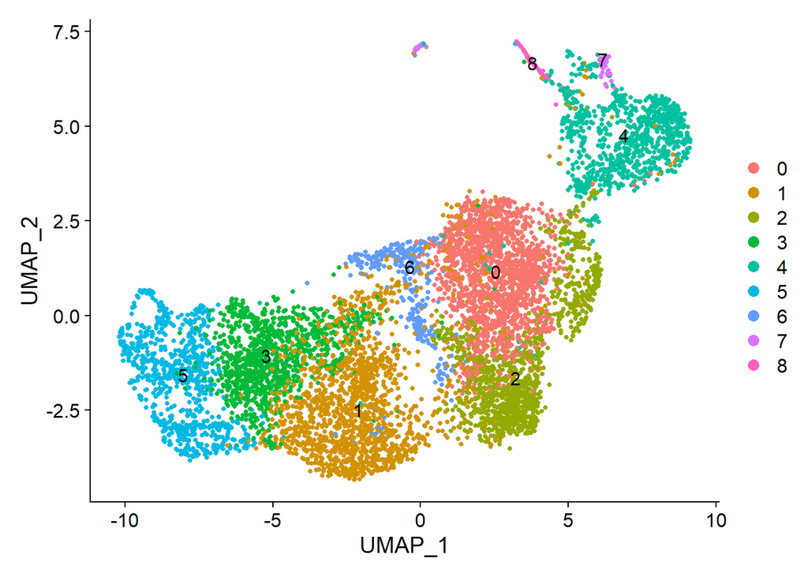

```r
Idents(psor_ife) = "integrated_snn_res.0.4"
DimPlot(psor_ife, reduction="umap", label=T, pt.size = 1)
```

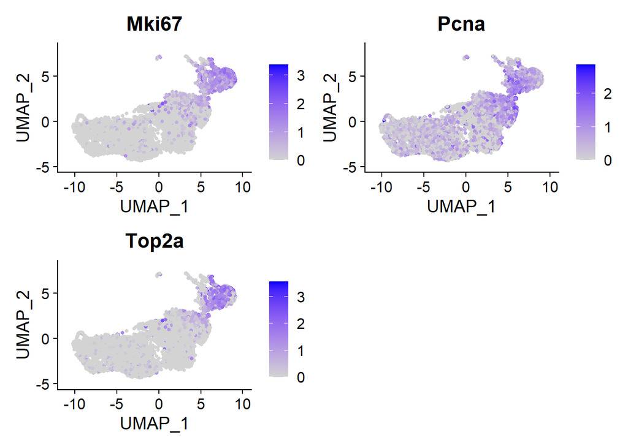

```r
FeaturePlot(object = psor_ife, features = c('Mki67','Pcna','Top2a'), cols = c("lightgrey", "blue"), pt.size = 1)
```

We subsetted this group of “cycling” cells, regressed out cell cycle scores, and reclustered them to distinguish between basal and spinous cycling cells.

## Subsetting

```r
Idents(psor_ife) = "integrated_snn_res.0.4"
DefaultAssay(psor_ife) = "RNA"
psor_ife_cyc = subset(psor_ife, idents = 4)
```

## Integration

```r
hu.list <- SplitObject(psor_ife_cyc, split.by = "orig.ident")
# Normalize all objects
for (i in 1:length(hu.list)) {
  hu.list[[i]] <- NormalizeData(hu.list[[i]], verbose = FALSE)
  hu.list[[i]] <- FindVariableFeatures(hu.list[[i]], selection.method = "vst",
                                       nfeatures = 2000, verbose = FALSE)
  print(i)
}
```

```
## [1] 1
## [1] 2
## [1] 3
## [1] 4
```

```r
hu.anchors <- FindIntegrationAnchors(object.list = hu.list, dims = 1:30)
psor_ife_cyc_int <- IntegrateData(anchorset = hu.anchors, dims = 1:30)
DefaultAssay(psor_ife_cyc_int) <- "integrated"
```

## Preprocessing

```r
psor_ife_cyc_int <- ScaleData(psor_ife_cyc_int, verbose = FALSE, vars.to.regress = c("S.Score","G2M.Score","percent.mt","nFeature_RNA"))  # Tried only S.Score and G2M.Score and results look very similar
psor_ife_cyc_int <- RunPCA(psor_ife_cyc_int, npcs = 30, verbose = FALSE)
psor_ife_cyc_int <- RunUMAP(psor_ife_cyc_int, reduction = "pca", dims = 1:30)
```

```r
setwd("C:/Users/Ji Lab/Documents/JID manuscript/Psoriasis/psor_int_filt/psor_ifeish/psor_ife/psor_ife_cyc_int")
png("psor_ife_cyc_int_labelbyorigident.png", units = "in", height = 5, width = 6, res=300)
p1 <- DimPlot(psor_ife_cyc_int, reduction = "umap", group.by = "orig.ident")
print(p1)
dev.off()
```

## Clustering

```r
all_res = c(0.1,0.2,0.4,0.6,0.8,1.0,1.2)
psor_ife_cyc_int <- FindNeighbors(psor_ife_cyc_int, dims = 1:30, verbose = T)
for (i in all_res){
  psor_ife_cyc_int <- FindClusters(psor_ife_cyc_int, resolution = i, verbose = FALSE)
}
```

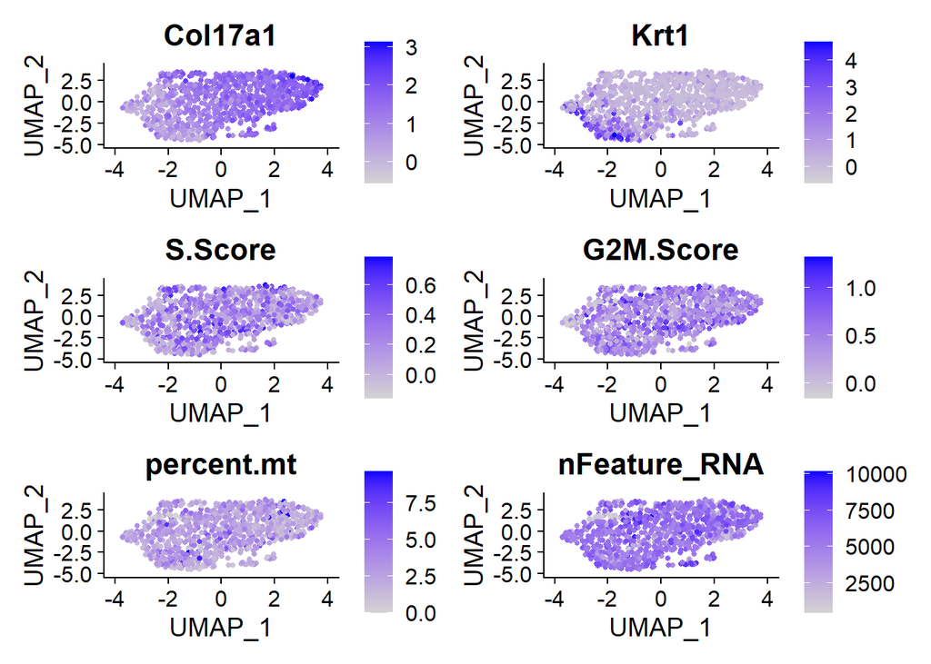

```r
FeaturePlot(psor_ife_cyc_int,features = c("Col17a1","Krt1","S.Score","G2M.Score","percent.mt","nFeature_RNA"))
```

```r
psor_ife_cyc_int
```

```
## An object of class Seurat
## 33053 features across 928 samples within 2 assays
## Active assay: integrated (2000 features, 2000 variable features)
##  1 other assay present: RNA
##  2 dimensional reductions calculated: pca, umap
```

## UMAPs, Feature plots, and Marker Lists

### UMAPS

```r
#umaps
setwd('C:/Users/Ji Lab/Documents/JID manuscript/Psoriasis/psor_int_filt/psor_ifeish/psor_ife/psor_ife_cyc_int')
all_res = c(0.1,0.2,0.4,0.6,0.8,1.0,1.2)
for (i in 1:length(all_res)){
  res = all_res[i]
  Idents(psor_ife_cyc_int) = paste("integrated_snn_res.",res,sep="")
  png(paste("psor_ife_cyc_int_UMAP",res,".png",sep=""), units = "in", height = 5, width = 5.5, res=300)
  p=DimPlot(psor_ife_cyc_int, reduction="umap", label=T, pt.size = 1)
  print(p)
  dev.off()
}
```

### Feature Plots

```r
#feature plots
DefaultAssay(psor_ife_cyc_int) = "RNA"
genes = list(c("Krt10",'Col17a1'),c("Lor",'Flg','Ivl','Klk7'),c("Mki67",'Pcna','Top2a'), c("Itga6", "Itgb4", "Itgb1", "Krt14", "Krt5",'Col17a1'), c("Krt79","Epcam", "Sox9"))
setwd('C:/Users/Ji Lab/Documents/JID manuscript/Psoriasis/psor_int_filt/psor_ifeish/psor_ife/psor_ife_cyc_int')
for (i in 1:length(genes)){
  png(paste("psor_ife_cyc_int", paste(genes[[i]], collapse = '.'),"_noaxes_nolegend.png", sep=""), units = "in", height = 6, width = 10, res=300)
  p= FeaturePlot(object = psor_ife_cyc_int, features = genes[[i]], cols = c("lightgrey", "blue"), pt.size = 1)
  p = p + NoLegend() + NoAxes()
  print(p)
  dev.off()
}
#additional, individual feature plots
genes = c("Col17a1","Krt10","Mki67","Top2a","Klk7","Krt1","Itga6","Itgb4","Mt1","Pcna","Lor","Flg","Ivl")

genes_match = genes[genes %in% rownames(psor_ife_cyc_int)]
for (i in 1:length(genes_match))
{
  png(paste("psor_ife_cyc_int_",genes_match[i],"_noaxes_nolegend_pt1.png",sep=""), units = "in", height = 5, width = 5, res=300)
  p=FeaturePlot(object = psor_ife_cyc_int, features = genes_match[i], cols = c("lightgrey", "blue"), pt.size = 1, order=T)
  p = p + NoLegend() + NoAxes()
  print(p)
  dev.off()
}
```

Label by phase

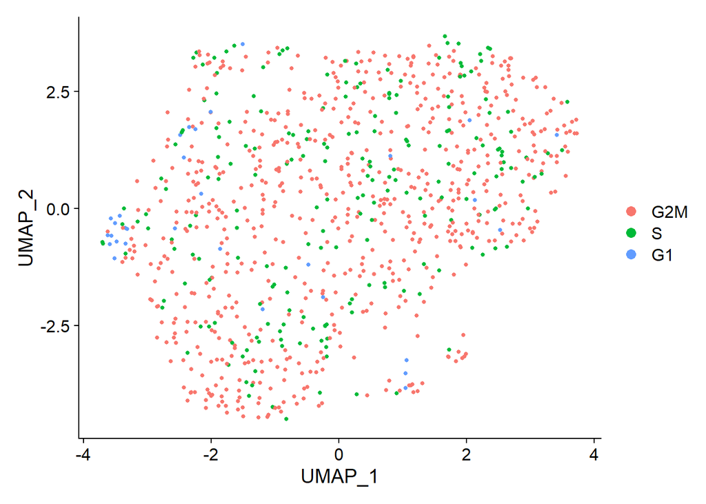

```r
Idents(psor_ife_cyc_int) = "Phase"
DimPlot(psor_ife_cyc_int, reduction = "umap")
```

### Marker Lists

```r
#SAVING MARKER LISTS
all_res = c(0.1,0.2,0.4,0.6,0.8,1.0,1.2)
for (i in all_res){
  Idents(psor_ife_cyc_int) = paste("integrated_snn_res.", i, sep = '')
  psor_ife_cyc_int.markers = FindAllMarkers(psor_ife_cyc_int, only.pos = TRUE, min.pct = 0.25, logfc.threshold = 0.25)
  write.csv(psor_ife_cyc_int.markers, paste0("C:/Users/Ji Lab/Documents/JID manuscript/Psoriasis/psor_int_filt/psor_ifeish/psor_ife/psor_ife_cyc_int/psor_ife_cyc_int.markers_",i,".csv"))
}
```

At clustering resolution 0.2, we identified cluster 0 as representing basal cycling cells, and cluster 1 as representing spinous cycling cells.

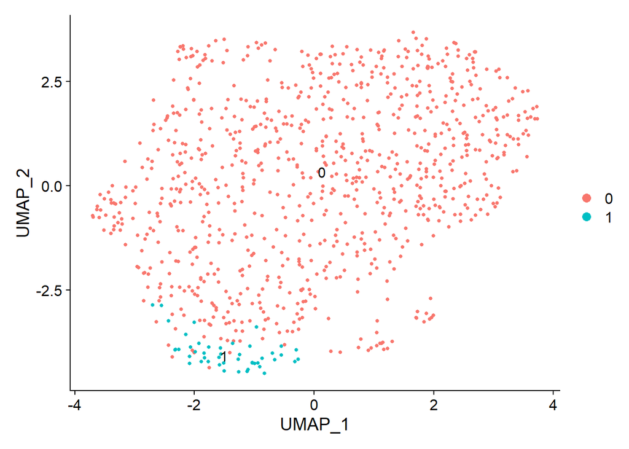

```r
Idents(psor_ife_cyc_int) = "integrated_snn_res.0.2"
DimPlot(psor_ife_cyc_int, reduction="umap", label=T, pt.size = 1)
```

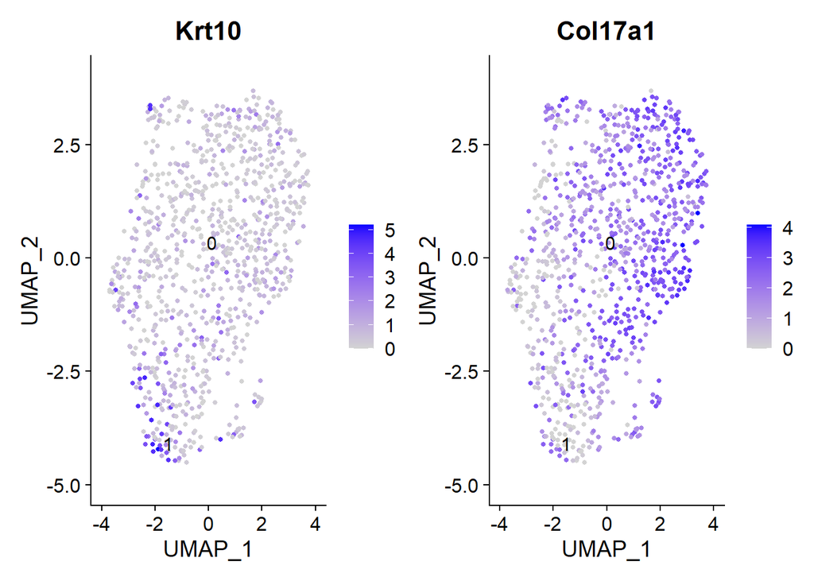

```r
FeaturePlot(psor_ife_cyc_int, features = c('Krt10','Col17a1') , label=T, pt.size = 1)
```

### Saving psor_ife_cyc_int

```r
setwd('C:/Users/Ji Lab/Documents/JID manuscript/Psoriasis/psor_int_filt/psor_ifeish/psor_ife/psor_ife_cyc_int')
saveRDS(psor_ife_cyc_int, file="psor_ife_cyc_int.Rds")
```

### Saving Metadata

```r
psor_ife_cyc_int_metadata = as.matrix(psor_ife_cyc_int@meta.data)
setwd('C:/Users/Ji Lab/Documents/JID manuscript/Psoriasis/psor_int_filt/psor_ifeish/psor_ife/psor_ife_cyc_int')
write.table(psor_ife_cyc_int_metadata,file="psor_ife_cyc_int_metadata.txt",sep="\t",col.names=T,row.names=T)
```

# PROPORTION ANALYSIS

## Proportion of cycling cells that are basal/spinous

First, we generate a table of proportions of basal and spinous cells that are cycling, with each cell representing the proportion of cycling cells that are either basal or spinous, for each sample.

```r
cyc_prop_table = prop.table(table(psor_ife_cyc_int_metadata[,"integrated_snn_res.0.2"],psor_ife_cyc_int_metadata[,"orig.ident"]),margin=2)
rownames(cyc_prop_table) = c("Basal","Spinous")
```

```r
cyc_prop_table
```

```
##
##                IMQ_1      IMQ_2   Normal_1   Normal_2
##   Basal   0.92307692 0.93181818 0.98091603 0.96313364
##   Spinous 0.07692308 0.06818182 0.01908397 0.03686636
```

## Proportion of basal/spinous cells that are cycling

The overall equation for calculating the proportion of Basal/Spinous cells that are cycling is as follows:

$$Proportion\,of\,Basal/Spinous\,Cells\,that\,are\,Cycling =
\dfrac{Cycling\,Basal/Spinous\,Cells}{All\,Basal/Spinous\,Cells}$$

The total number of basal/spinous cells is calculated by adding the number of cycling basal/spinous cells to the number of non-cycling basal/spinous cells identified in psor_ife.

Here, we calculate the proportion of non-cycling basal and spinous cells within the psor_ife dataset.

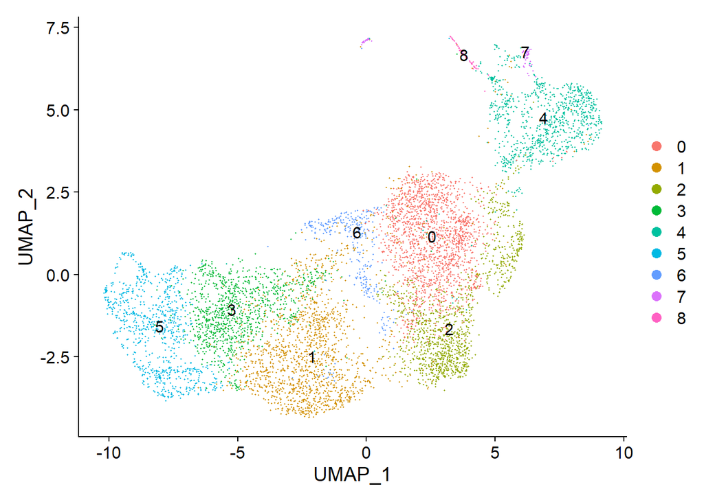

```r
DimPlot(psor_ife, reduction = "umap", label = TRUE)
```

The non-cycling spinous clusters were identified as clusters 1,3,5; and the non-cycling basal clusters were identified as clusters 0,2,6.

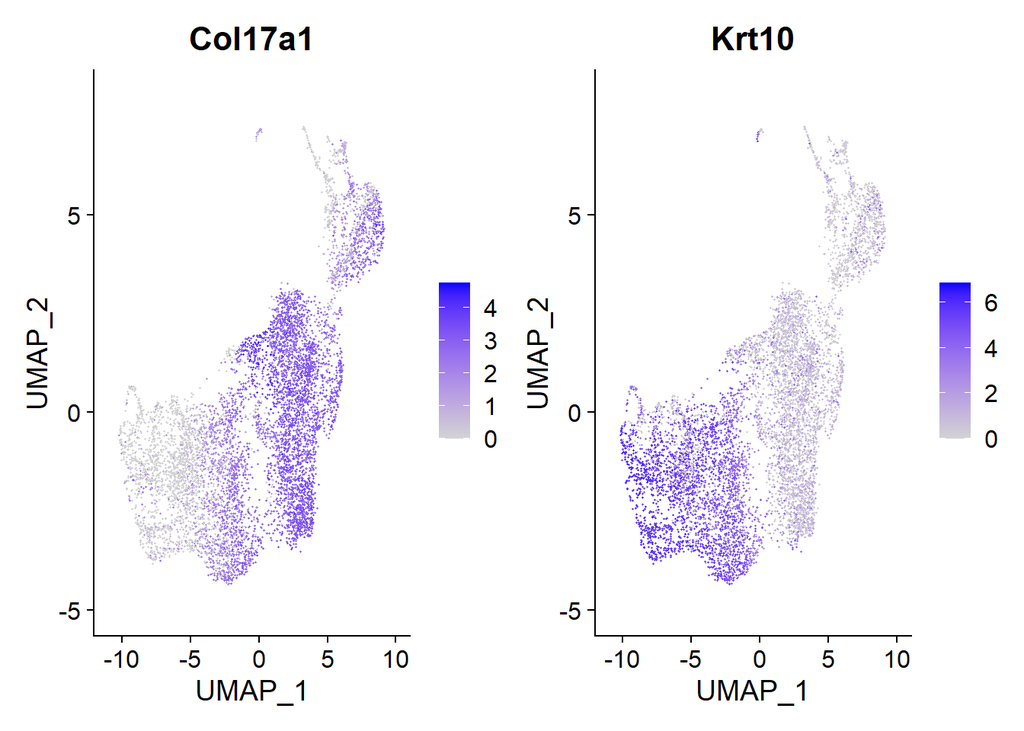

```r
FeaturePlot(psor_ife, features = c("Col17a1", "Krt10"))
```

We create a table of the number of cells from each sample that belong to each cluster.

```r
psor_ife_table = table(psor_ife$integrated_snn_res.0.4, psor_ife$orig.ident)
psor_ife_table
```

```
##
##     IMQ_1 IMQ_2 Normal_1 Normal_2
##   0   108    51     1260      300
##   1   165   117     1009      258
##   2    33    19      968      130
##   3   275   128      507      143
##   4   273   176      262      217
##   5   135    76      538       98
##   6    14     4      292        6
##   7    16    13       13       23
##   8     0     1        0       51
```

We then subset the table using the non-cycling basal and spinous clusters.

```r
spn_clus = as.character(c(1,3,5))
bas_clus = as.character(c(0,2,6))

psor_ife_spn = psor_ife_table[spn_clus,]
psor_ife_bas = psor_ife_table[bas_clus,]
```

We then create psor_ife_cyc_table, a table consisting of the number of cycling cells that are spinous/basal, for each sample.

```r
psor_ife_cyc_table = table(psor_ife_cyc_int$integrated_snn_res.0.2,psor_ife_cyc_int$orig.ident)
rownames(psor_ife_cyc_table) = c("Basal","Spinous")
psor_ife_cyc_table
```

```
##
##           IMQ_1 IMQ_2 Normal_1 Normal_2
##   Basal     252   164      257      209
##   Spinous    21    12        5        8
```

Now, that we have the number of spinous/basal cells that are cycling and the total number of basal/spinous cells, we can calculate the proportion of spinous/basal cells that are cycling for each sample.

```r
spn_prop = psor_ife_cyc_table[2,]/(psor_ife_cyc_table[2,] + apply(psor_ife_spn,2,sum))
print(spn_prop)
```

```
##       IMQ_1       IMQ_2    Normal_1    Normal_2
## 0.035234899 0.036036036 0.002428363 0.015779093
```

```r
bas_prop = psor_ife_cyc_table[1,]/(psor_ife_cyc_table[1,] + apply(psor_ife_bas,2,sum))
print(bas_prop)
```

```
##      IMQ_1      IMQ_2   Normal_1   Normal_2
## 0.61916462 0.68907563 0.09254591 0.32403101
```